# Week 6 Performance Evaluation

## Summary of *caret* Package

- Streamline the process for creating predictive models
  - Data splitting: createDataPartition()
  - Pre-processing: preProcess(), dummyVars(), nearZeroVar(), findCorrelation(),
  - Feature selection: score()/filter(), fit()
  - Model performance evaluation: confusionMatrix(), accuracy/kappa/roc/rmse for performance metrics
  - Model tuning using resampling: trainControl()/set.seed(), tuneLength, tuneGrid
  - Variable importance estimation: varImp()
  - Model comparison: resamples()
- Standardize interface for 200+ machine learning algorithms’ implementation
- Refer to [*caret* resource page](https://topepo.github.io/caret/index.html) for more details

## Hyperparamter Tuning with Caret

- Algorithms, parameters, default values
  - Decision tree: method = “rpart”, cp parameter
  - Regression (linear or logistic): no paramters to tune
- [list of tunable parameters in *caret*](https://topepo.github.io/caret/available-models.html)

## Summary of *sklearn* Package

- Streamline the process for creating and testing models
  - preprocessing: StandardScaler(), OneHotEncoder(), LabelEncoder(), transform(), fit_transform()
  - pipeline: make_pipeline(), Pipeline()
  - utils: resample(), shuffle()
  - model_selection: train_test_split(), GridSearchCV(), KFold(), LeaveOneout(), ShuffleSplit(), cross_val_score(), cross_val_predict()
  - metrics: confusion_matrix(), accuracy_score(), mean_squared_error(), roc_auc_score(), classification_report(), f1_score(), r2_score()
- Standardize interface for many machine learning algorithms
  - common training/prediction interface: fit(), predict(), predict_proba(), score()
  - tree: DecisionTreeClassifier(), DecisionTreeRegressor()
  - naive_bayes: GaussianNB(), MultinomialNB(), BernoulliNB()
  - ensemble: RandomForestRegression(), AdaBoostClassifier(), GradientBoostingClassifier()

## Decision Tree Modeling in Python

```python
import pandas as pd
import numpy as np
from sklearn.tree import DecisionTreeClassifier
from sklearn.model_selection import train_test_split, GridSearchCV, cross_val_score, cross_validate, ShuffleSplit, LeaveOneOut
from sklearn import metrics
from matplotlib import pyplot as plt
np.random.seed(66)

churn = pd.read_csv('churn.csv')
churn['international plan'] = churn['international plan'].map(dict(yes=1, no=0))
churn['voice mail plan'] = churn['voice mail plan'].map(dict(yes=1, no=0))
```

## Model Training/Testing

```python
num_vars = churn.select_dtypes(['int64', 'float64']).columns
X = churn[num_vars]
y = churn.churn

X_train, X_test, y_train, y_test = train_test_split(X, y, test_size=0.3, random_state=16)

clf = DecisionTreeClassifier()
clf.fit(X_train, y_train)
```

```
## DecisionTreeClassifier(class_weight=None, criterion='gini', max_depth=None,
##                        max_features=None, max_leaf_nodes=None,
##                        min_impurity_decrease=0.0, min_impurity_split=None,
##                        min_samples_leaf=1, min_samples_split=2,
##                        min_weight_fraction_leaf=0.0, presort=False,
##                        random_state=None, splitter='best')
```

```python
y_pred = clf.predict(X_test)
y_pred = np.where(y_pred==True, 1, 0)

plt.hist(y_pred, bins=2)
```

```
## (array([836., 164.]), array([0. , 0.5, 1. ]), <a list of 2 Patch objects>)
```

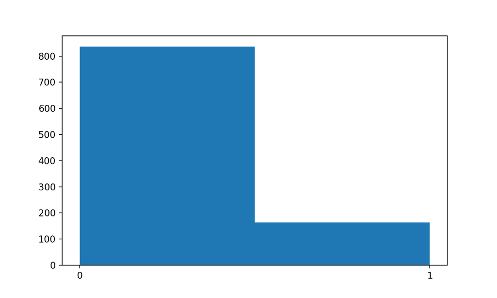

```python
plt.xticks(range(0, 2))
plt.show()
```

## Performance Reporting

```python
print(f"Accuracy: {round(metrics.accuracy_score(y_test, y_pred)*100, 2)}%")
```

```
## Accuracy: 90.0%
```

```python
df_confusion = pd.crosstab(y_test, y_pred)
df_confusion.columns.name = "Pred"
df_confusion
```

```
## Pred     0    1
## churn
## False  786   50
## True    50  114
```

```python
print(metrics.classification_report(y_test, y_pred))
```

```
##               precision    recall  f1-score   support
##
##        False       0.94      0.94      0.94       836
##         True       0.70      0.70      0.70       164
##
##     accuracy                           0.90      1000
##    macro avg       0.82      0.82      0.82      1000
## weighted avg       0.90      0.90      0.90      1000
```

## Hyperparameters’ Grid Search

```python
param_grid = {'criterion': ['gini', 'entropy'],
              'min_samples_split': [2, 10, 20, 30],
              'max_depth': [4, 5, 6, 10, 15, 20],
              'min_samples_leaf': [ 1, 5, 10],
              'max_leaf_nodes': [2, 5, 10, 20]}
grid = GridSearchCV(clf, param_grid, cv=5)
grid.fit(X_train, y_train)
```

```
## GridSearchCV(cv=5, error_score='raise-deprecating',
##              estimator=DecisionTreeClassifier(class_weight=None,
##                                               criterion='gini', max_depth=None,
##                                               max_features=None,
##                                               max_leaf_nodes=None,
##                                               min_impurity_decrease=0.0,
##                                               min_impurity_split=None,
##                                               min_samples_leaf=1,
##                                               min_samples_split=2,
##                                               min_weight_fraction_leaf=0.0,
##                                               presort=False, random_state=None,
##                                               splitter='best'),
##              iid='warn', n_jobs=None,
##              param_grid={'criterion': ['gini', 'entropy'],
##                          'max_depth': [4, 5, 6, 10, 15, 20],
##                          'max_leaf_nodes': [2, 5, 10, 20],
##                          'min_samples_leaf': [1, 5, 10],
##                          'min_samples_split': [2, 10, 20, 30]},
##              pre_dispatch='2*n_jobs', refit=True, return_train_score=False,
##              scoring=None, verbose=0)
```

```python
print(grid)
```

```
## GridSearchCV(cv=5, error_score='raise-deprecating',
##              estimator=DecisionTreeClassifier(class_weight=None,
##                                               criterion='gini', max_depth=None,
##                                               max_features=None,
##                                               max_leaf_nodes=None,
##                                               min_impurity_decrease=0.0,
##                                               min_impurity_split=None,
##                                               min_samples_leaf=1,
##                                               min_samples_split=2,
##                                               min_weight_fraction_leaf=0.0,
##                                               presort=False, random_state=None,
##                                               splitter='best'),
##              iid='warn', n_jobs=None,
##              param_grid={'criterion': ['gini', 'entropy'],
##                          'max_depth': [4, 5, 6, 10, 15, 20],
##                          'max_leaf_nodes': [2, 5, 10, 20],
##                          'min_samples_leaf': [1, 5, 10],
##                          'min_samples_split': [2, 10, 20, 30]},
##              pre_dispatch='2*n_jobs', refit=True, return_train_score=False,
##              scoring=None, verbose=0)
```

## Repeated Hold-Out Method

```python
bstrap = ShuffleSplit(n_splits=10, test_size=0.3, random_state=16)
grid_bstrap = GridSearchCV(clf, param_grid, cv=bstrap)
grid_bstrap.fit(X_train, y_train)
```

```
## GridSearchCV(cv=ShuffleSplit(n_splits=10, random_state=16, test_size=0.3, train_size=None),
##              error_score='raise-deprecating',
##              estimator=DecisionTreeClassifier(class_weight=None,
##                                               criterion='gini', max_depth=None,
##                                               max_features=None,
##                                               max_leaf_nodes=None,
##                                               min_impurity_decrease=0.0,
##                                               min_impurity_split=None,
##                                               min_samples_leaf=1,
##                                               min_samples_split=2,
##                                               min_weight_fraction_leaf=0.0,
##                                               presort=False, random_state=None,
##                                               splitter='best'),
##              iid='warn', n_jobs=None,
##              param_grid={'criterion': ['gini', 'entropy'],
##                          'max_depth': [4, 5, 6, 10, 15, 20],
##                          'max_leaf_nodes': [2, 5, 10, 20],
##                          'min_samples_leaf': [1, 5, 10],
##                          'min_samples_split': [2, 10, 20, 30]},
##              pre_dispatch='2*n_jobs', refit=True, return_train_score=False,
##              scoring=None, verbose=0)
```

## Hyperparameters for Best Performinig Model

```python
print(f"Accuracy: {round(grid_bstrap.best_score_*100, 2)}%")
```

```
## Accuracy: 94.24%
```

```python
for key, value in grid_bstrap.best_params_.items():
  print(f"Hyperparameter: {key}; Value: {value}")
```

```
## Hyperparameter: criterion; Value: entropy
## Hyperparameter: max_depth; Value: 10
## Hyperparameter: max_leaf_nodes; Value: 20
## Hyperparameter: min_samples_leaf; Value: 10
## Hyperparameter: min_samples_split; Value: 2
```

## Leave One Out

```python
loocv = LeaveOneOut()
lv_score = cross_val_score(clf, X, y, cv=loocv)
lv_score.mean()
```

```
## 0.9195919591959196
```